# Analysis

Mihailo Joksimovic

2/11/2019

## Basic info

This analysis file is split into two main parts. First part is concerned with Exploratory Data Analysis, where we’ll focus on exploring what we have inside the dataset, and the second part is concerned with predictions.

We’ll start our exploration by focusing on the data we have. Let’s see what we have in this dataset.

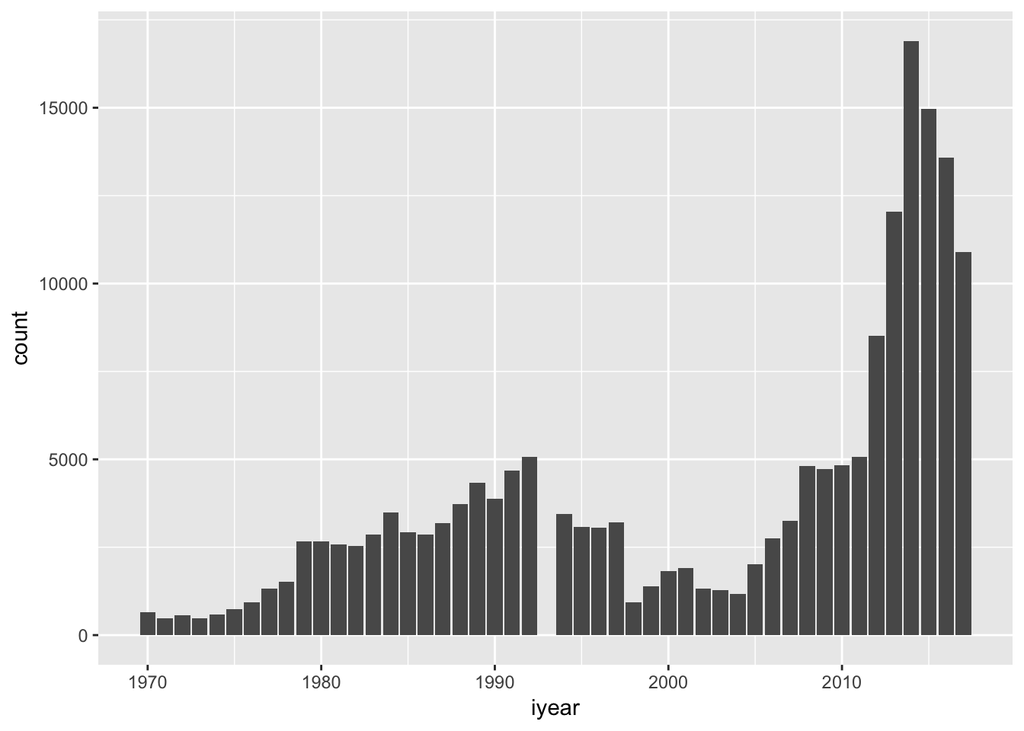

```r
ggplot(df, aes(x = iyear)) + geom_bar()
```

What we can see here is that data is being tracked from 1970s and there seems to be a single year that is missing.

Let’s see what the missing year is:

```r
df %>% filter(iyear > 1990, iyear < 2000) %>% distinct(iyear)
```

```
## # A tibble: 8 x 1
##   iyear
##   <int>
## 1  1991
## 2  1992
## 3  1994
## 4  1995
## 5  1996
## 6  1997
## 7  1998
## 8  1999
```

What we can see is that, for some reason, data seems to be missing for 1993. That’s ok, I guess we can live with that.

```r
small_set <- df %>% filter(iyear >= 2013)

# How many observations do we have?
count(small_set)
```

```
## # A tibble: 1 x 1
##       n
##   <int>
## 1 68391
```

Let’s see the # of attacks now and, for ease of analysis, let’s facet it by Region

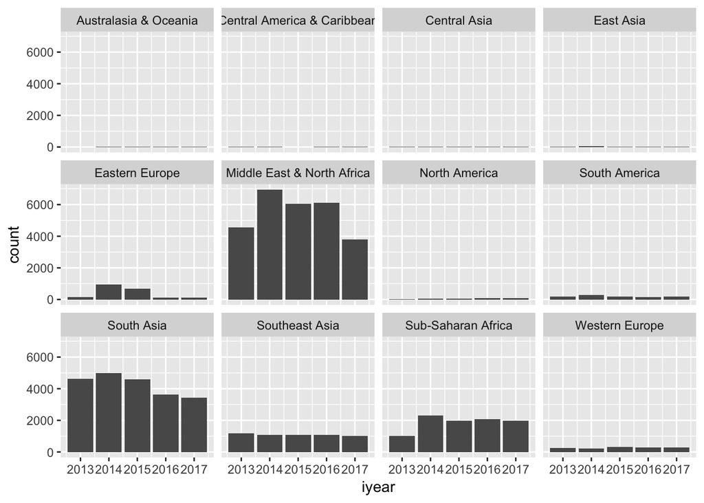

```r
ggplot(small_set, aes(iyear)) + geom_bar() + facet_wrap(~ region_txt)
```

That gives an interesting clue. So seems like Middle East, Nortf Africa and South Asia have higher number of attacks. We’ll put a better focus on that later on.

Let’s see a # of attacks per region.

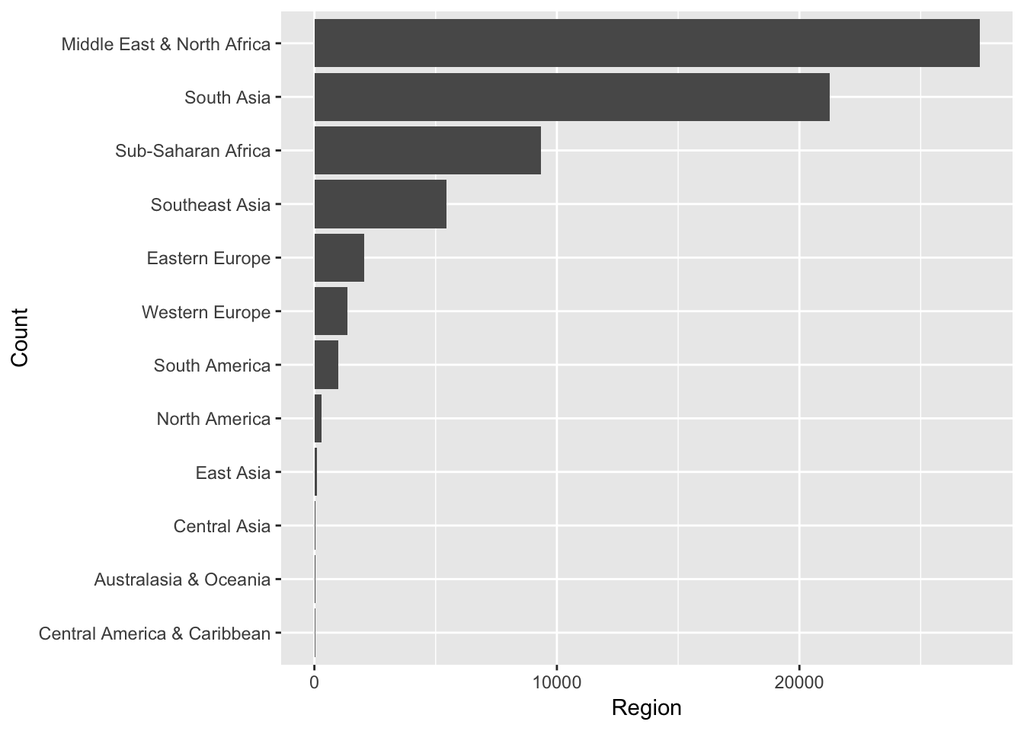

```r
by_region <- small_set %>%
  group_by(region_txt) %>%
  summarise(n = n())

ggplot(by_region) +
  geom_bar(aes(x = reorder(region_txt, n), y = n), stat = "identity") +
  coord_flip() +
  xlab("Count") +
  ylab("Region")
```

So we can confirm that previous observation makes sense really.

Let’s explore a bit more now. Which methods of attack are present?

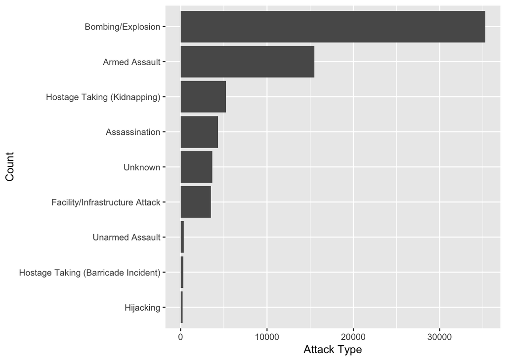

```r
by_attacktype <- small_set %>%
  group_by(attacktype1_txt) %>%
  summarise(n = n())

ggplot(by_attacktype) +
  geom_bar(aes(x = reorder(attacktype1_txt, n), y = n), stat = "identity") +
  coord_flip() +
  xlab("Count") +
  ylab("Attack Type")
```

[output not shown]